# VITAL - ClinVar - Data Analysis

André Soares

02/05/2020

## Filtered data analysis

- Creating an `UpSetR` plot to analyse any genes with 1 or more alleles (binary table) that are unique to a sample or shared between two or more.
- Filtering out any alleles occurring in controls AND patients.
- Removing alleles from from patient samples that appear in controls
- Using column “ALLELEID clinvar_20191118.vcf” as it should provide an individual ID to each allele found.
- Total number of altered genes excluding those present in controls:

```
## [1] 620
```

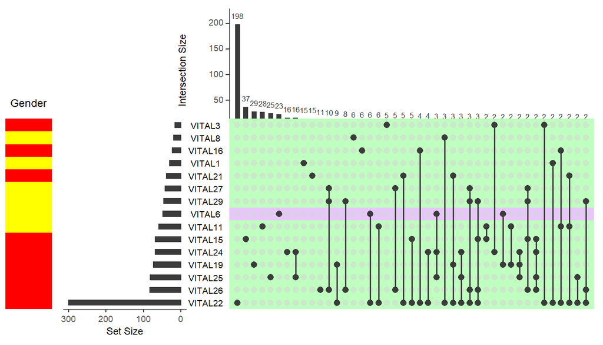

- Rows are samples (green for LVNC, purple for LVNC/HCM). Total number of altered genes per sample is plotted on the left vertical barchart.
- Columns depict “interactions”, i.e. altered genes unique to a sample or groups of genes shared by 2 or more samples. This is reflected on the vertical barchart on top.
- Heatmap on the left illustrates the gender of patients.

### List of genes shared by more than one patient (control-removed):

Total number of genes in more than one sample:

```
## [1] 204
```

Here’s all of them!

```
  [1] ABCA4                ABHD5                AC007326.4, PRODH
  [4] AC079594.2, IFT80    AC116366.3, RAD50    ACKR1
  [7] ACTN2                AHI1                 AIRE
 [10] AL645922.1, CFB      ALMS1                AMACR, C1QTNF3-AMACR
 [13] ANK1                 ANK2                 ANO5
 [16] AP4B1                AP5Z1                APC, AC008575.1
 [19] ARSB                 ATCAY                ATP8B1
 [22] BAG3                 BBS12                BBS2
 [25] BFSP2                BLM                  BRCA1
 [28] BRCA2                BRIP1                BSND
 [31] C2orf88, MSTN        CACNA1A              CACNA1C
 [34] CACNA1H              CACNA1S              CAV3
 [37] CENPJ                CEP290               CFTR
 [40] CHD7                 CHMP2B               CHRNE
 [43] CLCN1                CLIC5                CLN5, AC001226.2
```

[output cut: 53 more lines]

Table of variants per gene and per sample:

```r
library(kableExtra)
two_or_more_spl_f_freq_smVITAL %>%
  rename(Gene = `Homo sapiens (hg38) _Gene`) %>%
  kable() %>%
  kable_styling(bootstrap_options = c("striped", "hover", "condensed", "responsive"),
                full_width = F)
```

| Gene | VITAL1 | VITAL11 | VITAL15 | VITAL16 | VITAL19 | VITAL21 | VITAL22 | VITAL24 | VITAL25 | VITAL26 | VITAL27 | VITAL29 | VITAL3 | VITAL6 | VITAL8 |
| --- | --- | --- | --- | --- | --- | --- | --- | --- | --- | --- | --- | --- | --- | --- | --- |
| ABCA4 | 1 | 0 | 0 | 0 | 0 | 0 | 0 | 1 | 1 | 0 | 0 | 0 | 0 | 0 | 0 |
| ABHD5 | 0 | 0 | 0 | 0 | 0 | 0 | 0 | 1 | 1 | 0 | 0 | 0 | 0 | 0 | 0 |
| AC007326.4, PRODH | 0 | 0 | 0 | 0 | 1 | 0 | 0 | 1 | 1 | 0 | 0 | 0 | 0 | 0 | 0 |
| AC079594.2, IFT80 | 0 | 0 | 0 | 0 | 0 | 0 | 0 | 0 | 0 | 1 | 1 | 0 | 0 | 0 | 0 |
| AC116366.3, RAD50 | 0 | 0 | 0 | 0 | 0 | 0 | 2 | 2 | 0 | 0 | 0 | 0 | 0 | 0 | 1 |
| ACKR1 | 0 | 1 | 1 | 0 | 0 | 0 | 1 | 0 | 0 | 1 | 0 | 0 | 0 | 0 | 0 |
| ACTN2 | 0 | 0 | 0 | 0 | 0 | 0 | 1 | 0 | 0 | 0 | 0 | 0 | 0 | 1 | 0 |
| AHI1 | 0 | 1 | 0 | 0 | 0 | 1 | 1 | 0 | 0 | 0 | 0 | 0 | 0 | 0 | 0 |
| AIRE | 0 | 0 | 0 | 0 | 1 | 1 | 2 | 0 | 0 | 1 | 1 | 0 | 0 | 0 | 0 |
| AL645922.1, CFB | 0 | 0 | 0 | 0 | 0 | 0 | 0 | 0 | 0 | 1 | 0 | 0 | 0 | 1 | 0 |
| ALMS1 | 1 | 0 | 1 | 0 | 1 | 0 | 0 | 0 | 1 | 0 | 0 | 0 | 0 | 1 | 0 |
| AMACR, C1QTNF3-AMACR | 0 | 0 | 0 | 1 | 0 | 0 | 1 | 0 | 0 | 0 | 0 | 1 | 0 | 1 | 0 |
| ANK1 | 0 | 0 | 0 | 0 | 0 | 0 | 1 | 0 | 0 | 2 | 2 | 2 | 0 | 0 | 0 |
| ANK2 | 0 | 2 | 1 | 0 | 0 | 0 | 0 | 0 | 0 | 0 | 0 | 0 | 1 | 0 | 0 |
| ANO5 | 0 | 1 | 0 | 1 | 0 | 0 | 2 | 0 | 0 | 0 | 0 | 0 | 0 | 0 | 0 |
| AP4B1 | 0 | 0 | 0 | 0 | 0 | 0 | 0 | 0 | 0 | 1 | 1 | 1 | 0 | 0 | 0 |
| AP5Z1 | 0 | 0 | 0 | 0 | 0 | 0 | 1 | 0 | 0 | 0 | 0 | 0 | 0 | 2 | 0 |
| APC, AC008575.1 | 0 | 0 | 0 | 0 | 0 | 0 | 2 | 0 | 0 | 0 | 0 | 0 | 0 | 0 | 1 |
| ARSB | 0 | 0 | 0 | 0 | 0 | 0 | 2 | 0 | 0 | 1 | 0 | 0 | 0 | 0 | 0 |
| ATCAY | 0 | 0 | 0 | 0 | 0 | 1 | 1 | 0 | 0 | 0 | 0 | 0 | 0 | 0 | 0 |
| ATP8B1 | 0 | 0 | 0 | 0 | 0 | 0 | 0 | 0 | 0 | 1 | 1 | 1 | 0 | 0 | 0 |
| BAG3 | 0 | 0 | 0 | 0 | 0 | 0 | 1 | 2 | 2 | 0 | 0 | 0 | 0 | 1 | 0 |
| BBS12 | 0 | 0 | 0 | 0 | 0 | 0 | 0 | 0 | 0 | 1 | 0 | 1 | 0 | 0 | 0 |
| BBS2 | 0 | 0 | 1 | 0 | 0 | 0 | 0 | 1 | 1 | 1 | 0 | 0 | 0 | 0 | 0 |
| BFSP2 | 1 | 0 | 0 | 0 | 0 | 0 | 0 | 1 | 1 | 0 | 0 | 0 | 0 | 1 | 0 |
| BLM | 0 | 0 | 0 | 1 | 0 | 1 | 1 | 0 | 1 | 1 | 0 | 0 | 0 | 1 | 0 |
| BRCA1 | 0 | 0 | 0 | 0 | 0 | 0 | 3 | 1 | 1 | 0 | 0 | 0 | 0 | 0 | 0 |
| BRCA2 | 0 | 0 | 0 | 0 | 1 | 0 | 0 | 1 | 3 | 0 | 0 | 0 | 0 | 0 | 0 |
| BRIP1 | 0 | 0 | 0 | 0 | 0 | 0 | 0 | 0 | 0 | 1 | 1 | 0 | 0 | 0 | 0 |
| BSND | 0 | 1 | 0 | 0 | 1 | 0 | 1 | 0 | 0 | 0 | 0 | 0 | 0 | 0 | 0 |

[output cut: 174 more lines]